# DataSet : Regularities_by_liaisons_Trains_France.csv

# Analyse et Nettoyage des données

```python
import pandas as pd
import matplotlib.pyplot as plt
import plotly.express as px
import numpy as np
import datetime as dt
import seaborn as sns
```

```python
df1 = pd.read_csv("Regularities_by_liaisons_Trains_France.csv")
df2 = df1.copy();
```

# Decouverte du dataset

```python
pd.set_option("display.max_columns", None)
df2.head()
```

|  | Year | Month | Departure station | Arrival station | Average travel time (min) | Number of expected circulations | Number of cancelled trains | Number of late trains at departure | Average delay of late departing trains (min) | Average delay of all departing trains (min) | Comment (optional) delays at departure | Number of trains late on arrival | Average delay of late arriving trains (min) | Average delay of all arriving trains (min) | Comment (optional) delays on arrival | % trains late due to external causes (weather, obstacles, suspicious packages, malevolence, social movements, etc.) | % trains late due to railway infrastructure (maintenance, works) | % trains late due to traffic management (rail line traffic, network interactions) | % trains late due to rolling stock | % trains late due to station management and reuse of material | % trains late due to passenger traffic (affluence, PSH management, connections) | Number of late trains > 15min | Average train delay > 15min | Number of late trains > 30min | Number of late trains > 60min | Period | Delay due to external causes | Delay due to railway infrastructure | Delay due to traffic management | … |
| --- | --- | --- | --- | --- | --- | --- | --- | --- | --- | --- | --- | --- | --- | --- | --- | --- | --- | --- | --- | --- | --- | --- | --- | --- | --- | --- | --- | --- | --- | --- |
| 0 | 2019 | 7.0 | ANGOULEME | PARIS MONTPARNASSE | 131.914980 | 247.0 | 0.0 | 191.0 | 3.576353 | 2.678273 | NaN | 41.0 | 22.924797 | 5.233333 | NaN | 0.250000 | 0.150000 | 0.275000 | 0.125000 | 0.025000 | 0.175000 | 21.0 | 32.965873 | 7.0 | 2.0 | 2019-07 | 25.000000 | 15.000000 | 27.500000 | … |
| 1 | 2019 | 7.0 | PARIS MONTPARNASSE | LA ROCHELLE VILLE | 175.611570 | 242.0 | 0.0 | 178.0 | 9.780805 | 7.033609 | NaN | 47.0 | 27.085106 | 6.123967 | NaN | 0.200000 | 0.244444 | 0.266667 | 0.244444 | 0.000000 | 0.044444 | 35.0 | 32.057143 | 14.0 | 2.0 | 2019-07 | 20.000000 | 24.444444 | 26.666667 | … |
| 2 | 2019 | 7.0 | LE MANS | PARIS MONTPARNASSE | 62.395349 | 435.0 | 5.0 | 391.0 | 3.896974 | 3.529341 | NaN | 91.0 | 18.440659 | 4.430194 | Ce mois ci, la destination a été marquée par l... | 0.161765 | 0.323529 | 0.264706 | 0.147059 | 0.029412 | 0.073529 | 30.0 | 42.367241 | 13.0 | 4.0 | 2019-07 | 16.176471 | 32.352941 | 26.470588 | … |
| 3 | 2019 | 7.0 | ST MALO | PARIS MONTPARNASSE | 172.421053 | 114.0 | 0.0 | 101.0 | 1.950990 | 1.685673 | NaN | 15.0 | 20.618889 | 3.812135 | NaN | 0.153846 | 0.153846 | 0.230769 | 0.384615 | 0.000000 | 0.076923 | 8.0 | 27.620833 | 2.0 | 0.0 | 2019-07 | 15.384615 | 15.384615 | 23.076923 | … |
| 4 | 2019 | 7.0 | PARIS MONTPARNASSE | ST PIERRE DES CORPS | 67.310000 | 404.0 | 4.0 | 284.0 | 8.379108 | 5.803125 | NaN | 73.0 | 19.608447 | 4.176208 | NaN | 0.184615 | 0.123077 | 0.400000 | 0.169231 | 0.076923 | 0.046154 | 28.0 | 37.658333 | 12.0 | 3.0 | 2019-07 | 18.461538 | 12.307692 | 40.000000 | … |

Regardons la taille du dataset

```python
df2.shape
```

```
(7806, 32)
```

```python
df2.describe
```

```
<bound method NDFrame.describe of       Year  Month   Departure station             Arrival station  \
0     2019    7.0           ANGOULEME          PARIS MONTPARNASSE
1     2019    7.0  PARIS MONTPARNASSE           LA ROCHELLE VILLE
2     2019    7.0             LE MANS          PARIS MONTPARNASSE
3     2019    7.0             ST MALO          PARIS MONTPARNASSE
4     2019    7.0  PARIS MONTPARNASSE         ST PIERRE DES CORPS
...    ...    ...                 ...                         ...
7801  2020    5.0          PARIS LYON                 AVIGNON TGV
7802  2020    5.0          PARIS LYON        MARSEILLE ST CHARLES
7803  2020    5.0          PARIS LYON                       NIMES
7804  2020    5.0          PARIS LYON  SAINT ETIENNE CHATEAUCREUX
7805  2020    5.0              TOULON                  PARIS LYON

      Average travel time (min)  Number of expected circulations  \
0                    131.914980                            247.0
```

[output cut: 272 more lines]

On regarde le type des données du dataset

```python
df2.dtypes
```

```
Year                                                                                                                     int64
Month                                                                                                                  float64
Departure station                                                                                                       object
Arrival station                                                                                                         object
Average travel time (min)                                                                                              float64
Number of expected circulations                                                                                        float64
Number of cancelled trains                                                                                             float64
Number of late trains at departure                                                                                     float64
Average delay of late departing trains (min)                                                                           float64
Average delay of all departing trains (min)                                                                            float64
Comment (optional) delays at departure                                                                                 float64
Number of trains late on arrival                                                                                       float64
Average delay of late arriving trains (min)                                                                            float64
Average delay of all arriving trains (min)                                                                             float64
Comment (optional) delays on arrival                                                                                    object
% trains late due to external causes (weather, obstacles, suspicious packages, malevolence, social movements, etc.)    float64
% trains late due to railway infrastructure (maintenance, works)                                                       float64
% trains late due to traffic management (rail line traffic, network interactions)                                      float64
% trains late due to rolling stock                                                                                     float64
% trains late due to station management and reuse of material                                                          float64
% trains late due to passenger traffic (affluence, PSH management, connections)                                        float64
Number of late trains > 15min                                                                                          float64
Average train delay > 15min                                                                                            float64
Number of late trains > 30min                                                                                          float64
Number of late trains > 60min                                                                                          float64
Period                                                                                                                  object
Delay due to external causes                                                                                           float64
Delay due to railway infrastructure                                                                                    float64
Delay due to traffic management                                                                                        float64
Delay due to rolling stock                                                                                             float64
Delay due to station management and reuse of material                                                                  float64
Delay due to travellers taken into account                                                                             float64
dtype: object
```

# Modification des types Objects

On voit qu'il va falloir modifier departure station et arrival station qui sont des objets

```python
df2["Departure station"] = df2["Departure station"].astype(str)
df2["Arrival station"] = df2["Arrival station"].astype(str)
```

On fusionne les station de départ et arrivée pour avoir la ligne en une colonne

```python
df2["ligne"] = df2["Departure station"] + df2["Arrival station"]
```

# Description du Dataset

Après avoir parcouru ce dataset on comprend donc que celui ci tiens à jour l'historique de départ et arrivé de tout les trains sur chaque ligne present dans le dataset tout les mois et ce depuis 2015. On a plusieurs informations pour chaque ligne, les temps de trajet, le temps de retard causé par différentes raisons, le nombre de train avec un retard depassant un certain montant de temps ou encore des moyennes de temps de trajet.

# Analyse des données manquantes

On compte le nombre de données null par colonne et on regarde lesquels sont vide pour pouvoir les enlever par la suite

```python
valnul = df2.isna().sum()
#on divise par le nombre de ligne
ligne= df2.shape[0]
valmanquante = (valnul/ligne).sort_values()
valmanquante
```

```
Year                                                                                                                   0.000000
Period                                                                                                                 0.000000
Average delay of late departing trains (min)                                                                           0.000000
Number of late trains at departure                                                                                     0.000000
Number of cancelled trains                                                                                             0.000000
ligne                                                                                                                  0.000000
Arrival station                                                                                                        0.000000
Departure station                                                                                                      0.000000
Month                                                                                                                  0.000000
Average travel time (min)                                                                                              0.008071
Average delay of all departing trains (min)                                                                            0.008071
Number of expected circulations                                                                                        0.008071
Average delay of all arriving trains (min)                                                                             0.008071
Number of late trains > 15min                                                                                          0.008711
Number of late trains > 60min                                                                                          0.008711
Number of late trains > 30min                                                                                          0.008711
Number of trains late on arrival                                                                                       0.012811
Average delay of late arriving trains (min)                                                                            0.012939
Average train delay > 15min                                                                                            0.013707
Delay due to railway infrastructure                                                                                    0.034717
Delay due to external causes                                                                                           0.034717
Delay due to station management and reuse of material                                                                  0.034717
Delay due to traffic management                                                                                        0.034717
Delay due to rolling stock                                                                                             0.034717
% trains late due to station management and reuse of material                                                          0.034717
% trains late due to rolling stock                                                                                     0.034717
% trains late due to traffic management (rail line traffic, network interactions)                                      0.034717
Delay due to travellers taken into account                                                                             0.034717
% trains late due to external causes (weather, obstacles, suspicious packages, malevolence, social movements, etc.)    0.034717
% trains late due to passenger traffic (affluence, PSH management, connections)                                        0.034717
% trains late due to railway infrastructure (maintenance, works)                                                       0.034717
Comment (optional) delays on arrival                                                                                   0.769024
Comment (optional) delays at departure                                                                                 1.000000
dtype: float64
```

On remarque que les colonnes comments sont vides en grande partie.

# Supression des données manquantes/inutiles

On va convertir la colonne mois et année en datetime et en faire une seule colonne.

```python
df_time=[]
for i in df2.index:

    df_time.append(dt.datetime.strptime(str(df2.loc[i,'Year'])+":"+str(round(df2.loc[i,'Month'])), '%Y:%m'))

df2['time']=df_time
```

On peut donc supprimer les colonnes annee et mois.

```python
df2 = df2.drop(columns= ["Year","Month"])
```

On supprime les 2 colonnes comments vide

```python
del df2['Comment (optional) delays on arrival']
del df2['Comment (optional) delays at departure']
```

On ne s'interessera pas aux colonnes pourcentages on va donc drop toutes ces colonnes

```python
df2 = df2.drop(columns = ["% trains late due to external causes (weather, obstacles, suspicious packages, malevolence, social movements, etc.)","% trains late due to railway infrastructure (maintenance, works)",
                          "% trains late due to traffic management (rail line traffic, network interactions)","% trains late due to traffic management (rail line traffic, network interactions)",
                          "% trains late due to rolling stock","% trains late due to station management and reuse of material",
                          "% trains late due to passenger traffic (affluence, PSH management, connections)"])
```

On drop toutes les lignes contenant au moins une valeur Nan pour eviter d'avoir des valeurs vides qui fausseront les données.

```python
df = df2.copy()
df2.dropna(how = 'any',inplace=True)
```

```python
df2.shape
```

```
(7520, 24)
```

On a supprimé 286 lignes du dataset avec des valeurs manquantes.

On verifie que plus aucunes colonnes n'a de valeurs manquantes.

```python
valnul = df2.isna().sum()
valnul
```

```
Departure station                                        0
Arrival station                                          0
Average travel time (min)                                0
Number of expected circulations                          0
Number of cancelled trains                               0
Number of late trains at departure                       0
Average delay of late departing trains (min)             0
Average delay of all departing trains (min)              0
Number of trains late on arrival                         0
Average delay of late arriving trains (min)              0
Average delay of all arriving trains (min)               0
Number of late trains > 15min                            0
Average train delay > 15min                              0
Number of late trains > 30min                            0
Number of late trains > 60min                            0
Period                                                   0
Delay due to external causes                             0
Delay due to railway infrastructure                      0
Delay due to traffic management                          0
Delay due to rolling stock                               0
Delay due to station management and reuse of material    0
Delay due to travellers taken into account               0
ligne                                                    0
time                                                     0
dtype: int64
```

# Renommage des colonnes

On renomme les colonnes:

```python
df2.columns
```

```
Index(['Departure station', 'Arrival station', 'Average travel time (min)',
       'Number of expected circulations', 'Number of cancelled trains',
       'Number of late trains at departure',
       'Average delay of late departing trains (min)',
       'Average delay of all departing trains (min)',
       'Number of trains late on arrival',
       'Average delay of late arriving trains (min)',
       'Average delay of all arriving trains (min)',
       'Number of late trains > 15min', 'Average train delay > 15min',
       'Number of late trains > 30min', 'Number of late trains > 60min',
       'Period', 'Delay due to external causes',
       'Delay due to railway infrastructure',
       'Delay due to traffic management', 'Delay due to rolling stock',
       'Delay due to station management and reuse of material',
       'Delay due to travellers taken into account', 'ligne', 'time'],
      dtype='object')
```

```python
df2.columns = ["Station_depart","Station_arrivee", "Moyenne_tmps_trajet(min)", "Nb_trajet_attendu", "Nb_train_annule","Nb_trains_retard_depart", "Moyenne_tmps_retard_depart","Moyenne_tmps_depart_tout_trains","nombre_trains_retard_arrivee", "Moyenne_tmps_retard_arrivee","Moyenne_tmps_arrivee_tout_trains","Nombre_retard_trains>15min","Moyenne_retard_delai>15min","Nombre_retard_trains>30min","Moyenne_retard_delai>30min", "periode", "retard_cause_externe", "retard_cause_infrastructure_rail", "retard_cause_gestion_traffic","retard_cause_rolling_stock","retard_cause_gestion_station/materiel", "retard_cause_voyageur_prisencompte","ligne","time"]
```

```python
df2.columns
```

```
Index(['Station_depart', 'Station_arrivee', 'Moyenne_tmps_trajet(min)',
       'Nb_trajet_attendu', 'Nb_train_annule', 'Nb_trains_retard_depart',
       'Moyenne_tmps_retard_depart', 'Moyenne_tmps_depart_tout_trains',
       'nombre_trains_retard_arrivee', 'Moyenne_tmps_retard_arrivee',
       'Moyenne_tmps_arrivee_tout_trains', 'Nombre_retard_trains>15min',
       'Moyenne_retard_delai>15min', 'Nombre_retard_trains>30min',
       'Moyenne_retard_delai>30min', 'periode', 'retard_cause_externe',
       'retard_cause_infrastructure_rail', 'retard_cause_gestion_traffic',
       'retard_cause_rolling_stock', 'retard_cause_gestion_station/materiel',
       'retard_cause_voyageur_prisencompte', 'ligne', 'time'],
      dtype='object')
```

```python
df3 = df2.groupby("ligne").mean()
df3.shape
```

```
(130, 19)
```

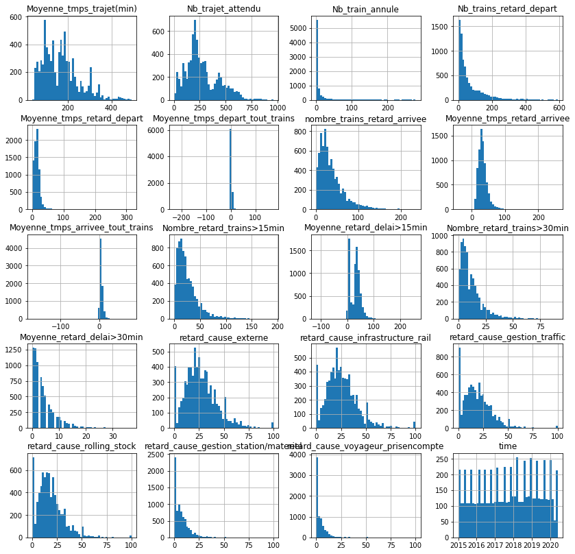

```python
# Histogrammes

df2.hist(
    bins=50,
    sharex=False,
    sharey=False,
    figsize=(14,14)
)
plt.show()
```

on a fait une moyenne des resultat sur toutes les années des differentes lignes

# Visualisation des données au travers de quelques graphs

```python
fig = px.bar(df3, y='Moyenne_tmps_trajet(min)',title="moyenne des temps de trajets par gares")
fig.show()
```

[interactive chart not shown]

On peut voir avec ce graph les trajets les plus longs en moyenne

```python
fig = px.bar(df3, y='Nb_train_annule', title= "Nombre de train annulé par ligne")
fig.show()
```

[interactive chart not shown]

On peut voir aussi les lignes ou le nombre de train annulé est le plus élevé avec ce graph.

# Visualisation de quelques données selon le temps

```python
df2_groupby_time=df2.groupby(by=["time"]).mean()
```

```python
print("\nFigure n°",i)
px.bar(df2_groupby_time, y="Moyenne_tmps_trajet(min)",title="evolution de la moyenne des temps de trajet (min) par mois").show()
```

```
Figure n° 7805
```

[interactive chart not shown]

Nous avons visualisé l'évolution de la moyenne des temps de trajets de 2015 a 2020

```python
print("\nFigure n°",i)
px.bar(df2_groupby_time, y="Nb_train_annule",title="Evolution du nombre de train annulé par mois").show()
```

```
Figure n° 7805
```

[interactive chart not shown]

# Heatmap

On va maintenant réaliser des pivot table pour réaliser des heatmaps.

Ces pivots tables seront des pivots tables en des stations départ et arrivée avec comme value une colonne du dataset pour voir les differences entre ligne de train.

```python
liste_colonnes_float=list(df2.loc[:, df2.dtypes == np.float64].columns)
```

```
Figure n° 7805
```

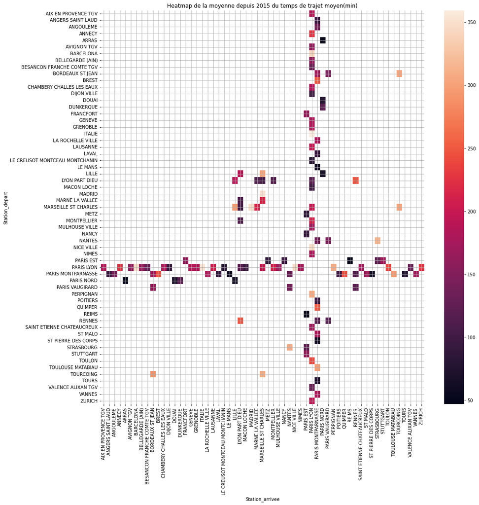

```
Ainsi les 3 trajets avec la plus grande moyenne de Moyenne_tmps_trajet(min) depuis 2015 par mois
Station_depart  Station_arrivee
ITALIE          PARIS LYON              359.402616
PARIS LYON      ITALIE                  352.533920
MADRID          MARSEILLE ST CHARLES    349.818048
Name: Moyenne_tmps_trajet(min), dtype: float64
```

```python
print("\nFigure n°",i)
plt.figure(figsize = (16,16))
data=df2.pivot_table(index="Station_depart",columns="Station_arrivee",values="Moyenne_tmps_trajet(min)",aggfunc="mean")
sns.heatmap(data,fmt="").grid()
plt.title("Heatmap de la moyenne depuis 2015 du "+"temps de trajet moyen(min)")
plt.show()
print("Ainsi les 3 trajets avec la plus grande moyenne de "+"Moyenne_tmps_trajet(min)"+" depuis 2015 par mois")
print(df2.groupby(by=["Station_depart","Station_arrivee"])["Moyenne_tmps_trajet(min)"].mean().sort_values(ascending=False).head(3),"\n\n")
```

On a fait une pivot table avec le temps de trajet moyen mais on peut le faire avec le nombre de train annulé :

```
Figure n° 7805
```

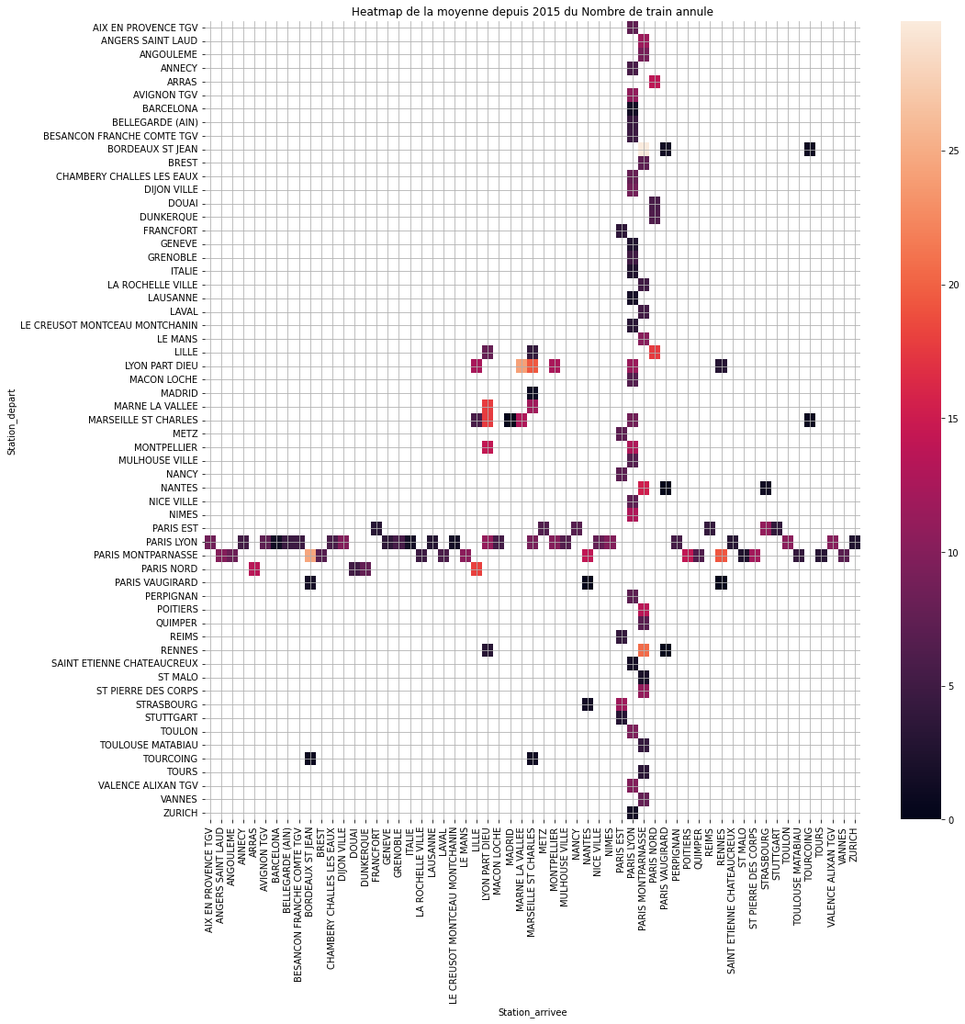

```
Ainsi les 3 trajets avec la plus grande moyenne de Nb_train_annule depuis 2015 par mois
Station_depart      Station_arrivee
BORDEAUX ST JEAN    PARIS MONTPARNASSE    29.848485
PARIS MONTPARNASSE  BORDEAUX ST JEAN      24.590909
LYON PART DIEU      MARNE LA VALLEE       24.206897
Name: Nb_train_annule, dtype: float64
```

```python
print("\nFigure n°",i)
plt.figure(figsize = (16,16))
data=df2.pivot_table(index="Station_depart",columns="Station_arrivee",values="Nb_train_annule",aggfunc="mean")
sns.heatmap(data,fmt="").grid()
plt.title("Heatmap de la moyenne depuis 2015 du "+"Nombre de train annule")
plt.show()
print("Ainsi les 3 trajets avec la plus grande moyenne de "+"Nb_train_annule"+" depuis 2015 par mois")
print(df2.groupby(by=["Station_depart","Station_arrivee"])["Nb_train_annule"].mean().sort_values(ascending=False).head(3),"\n\n")
```

On va faire une pivot table pour pouvoir rassember les données qui nous interessent en fonction du temps et etudier ce dataset enrichi.

```python
table = pd.pivot_table(df2, values=["Moyenne_tmps_retard_depart"], index= ["time"], columns= ["Station_depart"])
table = table.dropna(axis=1)
table.head()
```

| Station_depart time | Moyenne_tmps_retard_depart AIX EN PROVENCE TGV | Moyenne_tmps_retard_depart ANGERS SAINT LAUD | Moyenne_tmps_retard_depart ANGOULEME | Moyenne_tmps_retard_depart ARRAS | Moyenne_tmps_retard_depart AVIGNON TGV | Moyenne_tmps_retard_depart BESANCON FRANCHE COMTE TGV | Moyenne_tmps_retard_depart BORDEAUX ST JEAN | Moyenne_tmps_retard_depart BREST | Moyenne_tmps_retard_depart DIJON VILLE | Moyenne_tmps_retard_depart LAVAL | Moyenne_tmps_retard_depart LE CREUSOT MONTCEAU MONTCHANIN | Moyenne_tmps_retard_depart LE MANS | Moyenne_tmps_retard_depart LILLE | Moyenne_tmps_retard_depart LYON PART DIEU | Moyenne_tmps_retard_depart MACON LOCHE | Moyenne_tmps_retard_depart MARSEILLE ST CHARLES | Moyenne_tmps_retard_depart METZ | Moyenne_tmps_retard_depart MONTPELLIER | Moyenne_tmps_retard_depart MULHOUSE VILLE | Moyenne_tmps_retard_depart NANTES | Moyenne_tmps_retard_depart NIMES | Moyenne_tmps_retard_depart PARIS LYON | Moyenne_tmps_retard_depart PARIS MONTPARNASSE | Moyenne_tmps_retard_depart PARIS NORD | Moyenne_tmps_retard_depart POITIERS | Moyenne_tmps_retard_depart QUIMPER | Moyenne_tmps_retard_depart RENNES | Moyenne_tmps_retard_depart ST PIERRE DES CORPS | Moyenne_tmps_retard_depart STRASBOURG | … |
| --- | --- | --- | --- | --- | --- | --- | --- | --- | --- | --- | --- | --- | --- | --- | --- | --- | --- | --- | --- | --- | --- | --- | --- | --- | --- | --- | --- | --- | --- | --- |
| 2015-01-01 | 26.058824 | 9.523810 | 24.622222 | 13.869565 | 22.393258 | 12.75 | 25.016129 | 33.0 | 13.985714 | 21.600000 | 11.720000 | 16.789474 | 16.320860 | 20.245747 | 20.581395 | 23.785591 | 13.500000 | 19.873162 | 15.416667 | 12.690476 | 12.769231 | 19.612595 | 19.830958 | 18.841721 | 24.000000 | 7.500000 | 15.613095 | 36.968750 | 11.171875 | … |
| 2015-02-01 | 17.326087 | 12.928571 | 13.909091 | 9.516129 | 17.516484 | 12.20 | 19.981132 | 16.0 | 27.481013 | 13.827586 | 17.214286 | 22.535714 | 11.813773 | 17.614682 | 20.448276 | 17.968350 | 13.444444 | 22.928571 | 16.722222 | 44.290541 | 16.727273 | 16.749545 | 19.082957 | 20.895833 | 13.046154 | 19.000000 | 23.461538 | 21.407407 | 16.468085 | … |
| 2015-03-01 | 14.684211 | 14.675676 | 11.913043 | 11.586207 | 16.839080 | 6.00 | 13.914286 | 6.0 | 14.833333 | 21.888889 | 12.523810 | 24.921053 | 16.086370 | 16.084749 | 11.062500 | 20.236645 | 13.351351 | 23.044737 | 22.083333 | 15.282609 | 17.846154 | 15.567670 | 15.055357 | 13.934921 | 15.000000 | 22.000000 | 13.650000 | 19.840000 | 9.224490 | … |
| 2015-04-01 | 18.373134 | 27.000000 | 21.162791 | 16.825000 | 18.125000 | 9.25 | 17.796117 | 18.0 | 14.285714 | 12.708333 | 14.612903 | 20.941176 | 13.966339 | 15.791878 | 15.920000 | 19.169940 | 13.888889 | 24.880556 | 14.687500 | 11.447368 | 18.458333 | 17.717376 | 12.432242 | 15.868484 | 15.222222 | 15.666667 | 14.079670 | 16.973684 | 6.215909 | … |
| 2015-05-01 | 16.490909 | 13.783784 | 16.743590 | 19.885714 | 14.851852 | 7.60 | 14.140496 | 18.0 | 14.838710 | 22.333333 | 13.656250 | 28.063830 | 20.101970 | 17.618064 | 15.925926 | 15.469673 | 19.250000 | 21.324916 | 26.250000 | 6.229730 | 24.422222 | 20.093987 | 15.426488 | 18.401973 | 17.705882 | 12.000000 | 17.166667 | 16.966667 | 14.387931 | … |

On réalise un graphique de corrélation des valeurs afin de voir les valeurs interessantes à étudier par pair.

# Problématique :

On se place d'un point de vue externe à la sncf notre objectif est de prevoir le temps moyen de retard au départ d'une gare.

Pour pouvoir répondre à cette question il nous faut un dataset

On réalise un groupby pour visualiser l'évolution de chaque station de départ dans le temps

```python
data = df2.groupby(by =["Station_depart", "time"]).mean()
```

On prend une gare de départ aléatoirement et on regarde si il y a une corrélation avec la moyenne nationale

```python
px.bar(data.xs("DOUAI"), y = "Moyenne_tmps_retard_depart", title = "Moyenne de temps de retard au depart par mois à la gare de Douai")
```

[interactive chart not shown]

```python
px.bar(df2.groupby("time").mean(), y = "Moyenne_tmps_retard_depart", title = "Moyenne de temps de retard au depart par mois")
```

[interactive chart not shown]

On peut donc en conclure d'après les graphiques que pour predire le temps moyen de retard on va avoir besoin d'étudier la situation de chaque ville independamment

On nettoie le nouveau dataset data.

```python
data = data.dropna()
```

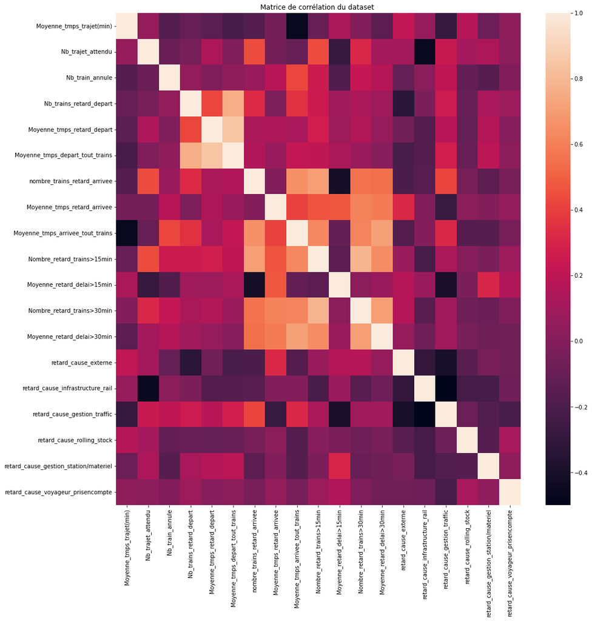

```python
plt.figure(figsize = (16,16))
sns.heatmap(data.xs("DOUAI").corr())
plt.title("Matrice de corrélation du dataset ")
plt.show()
```

# Sauvegarde et Exportation du Dataset

```python
data.to_csv("DonnéesSNCFtoML.csv")
```